# RNA-Seq - differential expression using DESeq2

## Volcano plot

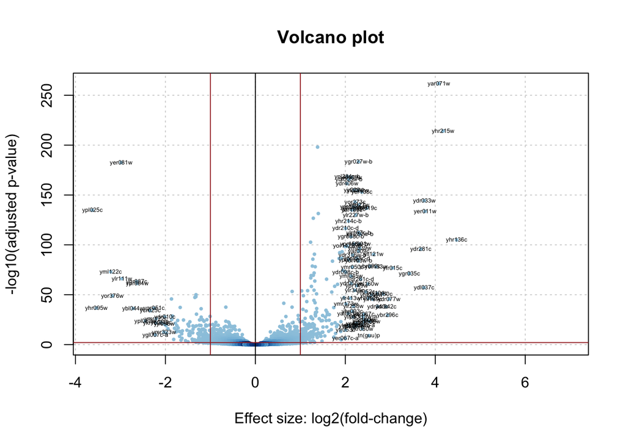

```r
alpha <- 0.01 # Threshold on the adjusted p-value
cols <- densCols(res.DESeq2$log2FoldChange, -log10(res.DESeq2$pvalue))
plot(res.DESeq2$log2FoldChange, -log10(res.DESeq2$padj), col=cols, panel.first=grid(),
     main="Volcano plot", xlab="Effect size: log2(fold-change)", ylab="-log10(adjusted p-value)",
     pch=20, cex=0.6)
abline(v=0)
abline(v=c(-1,1), col="brown")
abline(h=-log10(alpha), col="brown")

gn.selected <- abs(res.DESeq2$log2FoldChange) > 2 & res.DESeq2$padj < alpha
text(res.DESeq2$log2FoldChange[gn.selected],
     -log10(res.DESeq2$padj)[gn.selected],
     lab=rownames(res.DESeq2)[gn.selected ], cex=0.4)
```

## Check the expression levels of the most differentially expressed gene

It may be important to check the validity of our analysis by simply assessing the expression level of the most highly differential gene.

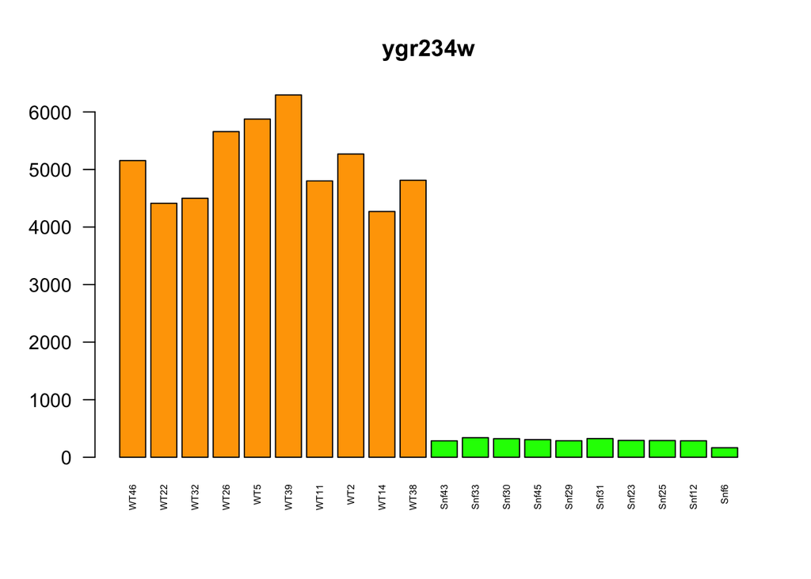

```r
gn.most.sign <- rownames(res.DESeq2)[1]
gn.most.diff.val <- counts(dds.norm, normalized=T)[gn.most.sign,]
barplot(gn.most.diff.val, col=col.pheno.selected, main=gn.most.sign, las=2, cex.names=0.5)
```

## Looking at the results with a MA plot

One popular diagram in dna chip analysis is the M versus A plot (MA plot) between two conditions $a$ and $b$. In this representation :

- M (Minus) is the log ratio of counts calculated for any gene.
  $$M_g = log2(\bar{x}_{g,a}) - log2(\bar{x}_{g,b})$$
- A (add) is the average log counts which corresponds to an estimate of the gene expression level.
  $$A_g = \frac{1}{2}(log2(\bar{x}_g,a) + log2(\bar{x}_g,b))$$

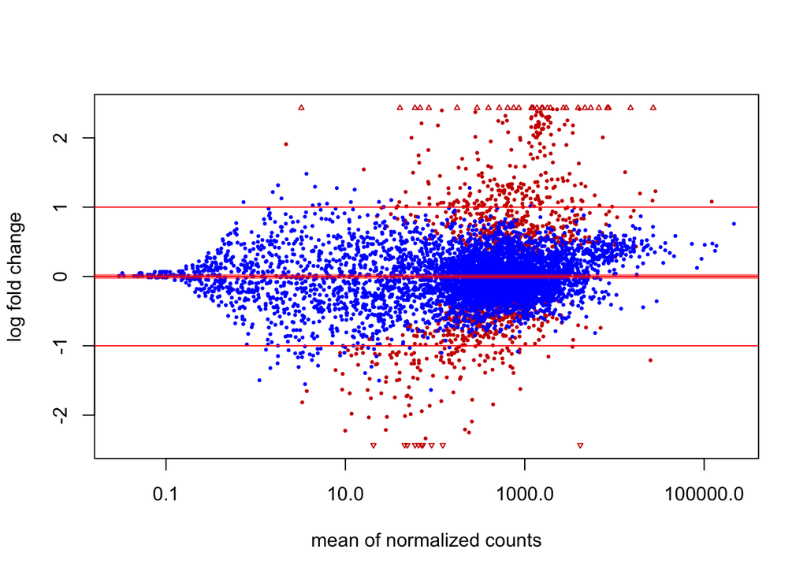

```r
## Draw a MA plot.
## Genes with adjusted p-values below 1% are shown
plotMA(res.DESeq2, colNonSig = "blue")
abline(h=c(-1:1), col="red")
```

## Hierarchical clustering

To ensure that the selected genes distinguish well between “treated”" and “untreated” condition we will perform a hierachical clustering using the **`heatmap.2()`** function from the gplots library.

```r
## We select gene names based on FDR (1%)
gene.kept <- rownames(res.DESeq2)[res.DESeq2$padj <= alpha & !is.na(res.DESeq2$padj)]

## We retrieve the normalized counts for gene of interest
count.table.kept <- log2(count.table + 1)[gene.kept, ]
dim(count.table.kept)
```

```
[1] 1953   96
```

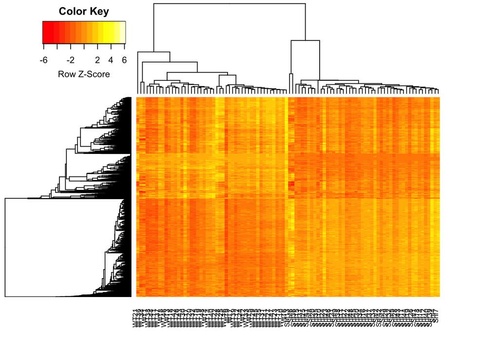

```r
## Install the gplots library if needed then load it
if(!require("gplots")){
  install.packages("gplots")
}
library("gplots")

## Perform the hierarchical clustering with
## A distance based on Pearson-correlation coefficient
## and average linkage clustering as agglomeration criteria
heatmap.2(as.matrix(count.table.kept),
          scale="row",
          hclust=function(x) hclust(x,method="average"),
          distfun=function(x) as.dist((1-cor(t(x)))/2),
          trace="none",
          density="none",
          labRow="",
          cexCol=0.7)
```

```r
# Export the DESeq2 result table
dir.results <- "~/ASG/practicals/rnaseq_diff_Snf2/results"
dir.create(dir.results, showWarnings = FALSE, recursive = TRUE)
DESeq2.table <- file.path(dir.results, "yeast_Snf2_vs_WT_DESeq2_diff.tsv")
write.table(res.DESeq2, file=DESeq2.table, col.names = TRUE, row.names = TRUE, sep="\t", quote = FALSE)
```

## Functional enrichment

We will now perform functional enrichment using the list of induced genes. This step will be performed using the gProfileR R library.

```r
library(gProfileR)

res.DESeq2.df <- na.omit(data.frame(res.DESeq2))
induced.sign <- rownames(res.DESeq2.df)[res.DESeq2.df$log2FoldChange >= 2 &  res.DESeq2.df$padj < alpha]
head(induced.sign)
```

```
[1] "ygr234w"   "yml123c"   "yor290c"   "yar071w"   "yhr215w"   "ygr027w-b"
```

```r
term.induced <- gprofiler(query=induced.sign, organism="scerevisiae")
term.induced <- term.induced[order(term.induced$p.value),]
kable(head(term.induced[,c("p.value", "term.name","intersection")], 10))
```

|  | p.value | term.name | intersection |
| --- | --- | --- | --- |
| 41 | 0 | RNA-DNA hybrid ribonuclease activity | YAR009C,YBL005W-B,YDR098C-B,YDR210C-D,YDR261C-D,YDR316W-B,YDR365W-B,YER138C,YER160C,YGR027W-B,YGR038C-B,YHR214C-B,YJR027W,YJR029W,YLR157C-B,YLR227W-B,YML039W,YML045W,YMR045C,YMR050C,YNL284C-B,YOL103W-… |
| 4 | 0 | DNA integration | YAR009C,YBL005W-B,YDR098C-B,YDR210C-D,YDR261C-D,YDR316W-B,YDR365W-B,YER138C,YER160C,YGR027W-B,YGR038C-B,YHR214C-B,YJR027W,YJR029W,YLR157C-B,YLR227W-B,YML039W,YML045W,YMR045C,YMR050C,YNL284C-B,YOL103W-… |
| 47 | 0 | RNA-directed DNA polymerase activity | YAR009C,YBL005W-B,YDR098C-B,YDR210C-D,YDR261C-D,YDR316W-B,YDR365W-B,YER138C,YER160C,YGR027W-B,YGR038C-B,YHR214C-B,YJR027W,YJR029W,YLR157C-B,YLR227W-B,YML039W,YML045W,YMR045C,YMR050C,YNL284C-B,YOL103W-… |
| 31 | 0 | aspartic-type peptidase activity | YBL005W-B,YDR098C-B,YDR210C-D,YDR261C-D,YDR316W-B,YDR365W-B,YER138C,YER160C,YGR027W-B,YGR038C-B,YHR214C-B,YJR027W,YJR029W,YLR157C-B,YLR227W-B,YML039W,YML045W,YMR045C,YMR050C,YNL284C-B,YOL103W-B,YOR142… |
| 33 | 0 | aspartic-type endopeptidase activity | YBL005W-B,YDR098C-B,YDR210C-D,YDR261C-D,YDR316W-B,YDR365W-B,YER138C,YER160C,YGR027W-B,YGR038C-B,YHR214C-B,YJR027W,YJR029W,YLR157C-B,YLR227W-B,YML039W,YML045W,YMR045C,YMR050C,YNL284C-B,YOL103W-B,YOR142… |
| 40 | 0 | endoribonuclease activity, producing 5’-phosphomonoesters | YAR009C,YBL005W-B,YDR098C-B,YDR210C-D,YDR261C-D,YDR316W-B,YDR365W-B,YER138C,YER160C,YGR027W-B,YGR038C-B,YHR214C-B,YJR027W,YJR029W,YLR157C-B,YLR227W-B,YML039W,YML045W,YMR045C,YMR050C,YNL284C-B,YOL103W-… |
| 46 | 0 | DNA-directed DNA polymerase activity | YAR009C,YBL005W-B,YDR098C-B,YDR210C-D,YDR261C-D,YDR316W-B,YDR365W-B,YER138C,YER160C,YGR027W-B,YGR038C-B,YHR214C-B,YJR027W,YJR029W,YLR157C-B,YLR227W-B,YML039W,YML045W,YMR045C,YMR050C,YNL284C-B,YOL103W-… |
| 45 | 0 | DNA polymerase activity | YAR009C,YBL005W-B,YDR098C-B,YDR210C-D,YDR261C-D,YDR316W-B,YDR365W-B,YER138C,YER160C,YGR027W-B,YGR038C-B,YHR214C-B,YJR027W,YJR029W,YLR157C-B,YLR227W-B,YML039W,YML045W,YMR045C,YMR050C,YNL284C-B,YOL103W-… |
| 38 | 0 | endonuclease activity, active with either ribo- or deoxyribonucleic acids and producing 5’-phosphomonoesters | YAR009C,YBL005W-B,YDR098C-B,YDR210C-D,YDR261C-D,YDR316W-B,YDR365W-B,YER138C,YER160C,YGR027W-B,YGR038C-B,YHR214C-B,YJR027W,YJR029W,YLR157C-B,YLR227W-B,YML039W,YML045W,YMR045C,YMR050C,YNL284C-B,YOL103W-… |
| 39 | 0 | endoribonuclease activity | YAR009C,YBL005W-B,YDR098C-B,YDR210C-D,YDR261C-D,YDR316W-B,YDR365W-B,YER138C,YER160C,YGR027W-B,YGR038C-B,YHR214C-B,YJR027W,YJR029W,YLR157C-B,YLR227W-B,YML039W,YML045W,YMR045C,YMR050C,YNL284C-B,YOL103W-… |

```r
res.DESeq2.df <- na.omit(data.frame(res.DESeq2))
repressed.sign <- rownames(res.DESeq2.df)[res.DESeq2.df$log2FoldChange <= -2 &  res.DESeq2.df$padj < alpha]
head(repressed.sign)
```

```
[1] "yer081w" "ypl025c" "yml122c" "ylr111w" "ygr087c" "ypr064w"
```

```r
term.repressed <- gprofiler(query=repressed.sign, organism="scerevisiae")
term.repressed <- term.repressed[order(term.repressed$p.value),]
kable(head(term.induced[,c("p.value", "term.name","intersection")], 10))
```

|  | p.value | term.name | intersection |
| --- | --- | --- | --- |
| 41 | 0 | RNA-DNA hybrid ribonuclease activity | YAR009C,YBL005W-B,YDR098C-B,YDR210C-D,YDR261C-D,YDR316W-B,YDR365W-B,YER138C,YER160C,YGR027W-B,YGR038C-B,YHR214C-B,YJR027W,YJR029W,YLR157C-B,YLR227W-B,YML039W,YML045W,YMR045C,YMR050C,YNL284C-B,YOL103W-… |
| 4 | 0 | DNA integration | YAR009C,YBL005W-B,YDR098C-B,YDR210C-D,YDR261C-D,YDR316W-B,YDR365W-B,YER138C,YER160C,YGR027W-B,YGR038C-B,YHR214C-B,YJR027W,YJR029W,YLR157C-B,YLR227W-B,YML039W,YML045W,YMR045C,YMR050C,YNL284C-B,YOL103W-… |
| 47 | 0 | RNA-directed DNA polymerase activity | YAR009C,YBL005W-B,YDR098C-B,YDR210C-D,YDR261C-D,YDR316W-B,YDR365W-B,YER138C,YER160C,YGR027W-B,YGR038C-B,YHR214C-B,YJR027W,YJR029W,YLR157C-B,YLR227W-B,YML039W,YML045W,YMR045C,YMR050C,YNL284C-B,YOL103W-… |
| 31 | 0 | aspartic-type peptidase activity | YBL005W-B,YDR098C-B,YDR210C-D,YDR261C-D,YDR316W-B,YDR365W-B,YER138C,YER160C,YGR027W-B,YGR038C-B,YHR214C-B,YJR027W,YJR029W,YLR157C-B,YLR227W-B,YML039W,YML045W,YMR045C,YMR050C,YNL284C-B,YOL103W-B,YOR142… |
| 33 | 0 | aspartic-type endopeptidase activity | YBL005W-B,YDR098C-B,YDR210C-D,YDR261C-D,YDR316W-B,YDR365W-B,YER138C,YER160C,YGR027W-B,YGR038C-B,YHR214C-B,YJR027W,YJR029W,YLR157C-B,YLR227W-B,YML039W,YML045W,YMR045C,YMR050C,YNL284C-B,YOL103W-B,YOR142… |
| 40 | 0 | endoribonuclease activity, producing 5’-phosphomonoesters | YAR009C,YBL005W-B,YDR098C-B,YDR210C-D,YDR261C-D,YDR316W-B,YDR365W-B,YER138C,YER160C,YGR027W-B,YGR038C-B,YHR214C-B,YJR027W,YJR029W,YLR157C-B,YLR227W-B,YML039W,YML045W,YMR045C,YMR050C,YNL284C-B,YOL103W-… |
| 46 | 0 | DNA-directed DNA polymerase activity | YAR009C,YBL005W-B,YDR098C-B,YDR210C-D,YDR261C-D,YDR316W-B,YDR365W-B,YER138C,YER160C,YGR027W-B,YGR038C-B,YHR214C-B,YJR027W,YJR029W,YLR157C-B,YLR227W-B,YML039W,YML045W,YMR045C,YMR050C,YNL284C-B,YOL103W-… |
| 45 | 0 | DNA polymerase activity | YAR009C,YBL005W-B,YDR098C-B,YDR210C-D,YDR261C-D,YDR316W-B,YDR365W-B,YER138C,YER160C,YGR027W-B,YGR038C-B,YHR214C-B,YJR027W,YJR029W,YLR157C-B,YLR227W-B,YML039W,YML045W,YMR045C,YMR050C,YNL284C-B,YOL103W-… |
| 38 | 0 | endonuclease activity, active with either ribo- or deoxyribonucleic acids and producing 5’-phosphomonoesters | YAR009C,YBL005W-B,YDR098C-B,YDR210C-D,YDR261C-D,YDR316W-B,YDR365W-B,YER138C,YER160C,YGR027W-B,YGR038C-B,YHR214C-B,YJR027W,YJR029W,YLR157C-B,YLR227W-B,YML039W,YML045W,YMR045C,YMR050C,YNL284C-B,YOL103W-… |
| 39 | 0 | endoribonuclease activity | YAR009C,YBL005W-B,YDR098C-B,YDR210C-D,YDR261C-D,YDR316W-B,YDR365W-B,YER138C,YER160C,YGR027W-B,YGR038C-B,YHR214C-B,YJR027W,YJR029W,YLR157C-B,YLR227W-B,YML039W,YML045W,YMR045C,YMR050C,YNL284C-B,YOL103W-… |

## Assess the effect of sample number on differential expression call

Using a loop, randomly select 10 times 2,5,10,15..45 samples from WT and Snf2 KO. Perform differential expression calls and draw a diagram showing the number of differential expressed genes.